# Who plays well together?

Player connections, rotation structure and coaching deployment in LTU women’s basketball (UBL 2025)

Mey Siv

2026-10-31

## Points and plus-minus can’t show who plays well *together*

- Results also depend on teammates, opponents and minutes played
- Individual stats say who is good, not which combinations work

**Question**

Which LTU pairings create more value than their individual ratings would predict?

## Data: 10 LTU games, 8 usable

- UBL women’s 2025 play-by-play: substitutions, shots, game clock, player IDs (UniSport / Sportradar feed)
- 2 of 10 games dropped: lineup tracking failed when a starter had no logged action before the first substitution
- Final scores for all 61 league games, used only for the league context at the end

## From raw events to a connection score

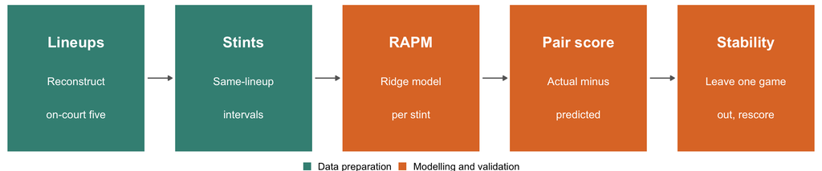

**Lineup prediction**
$$y_s = \beta_0 + \sum_p \beta_p x_{sp}
+ \sum_o \delta_o z_{so} + \varepsilon_s$$

**Connection score**
$$C_{ij} =
\frac{\sum_{s \ni i,j} d_s (y_s - \hat{y}_s)}
{\sum_{s \ni i,j} d_s}$$

## Some pairs outperform what their lineups predict

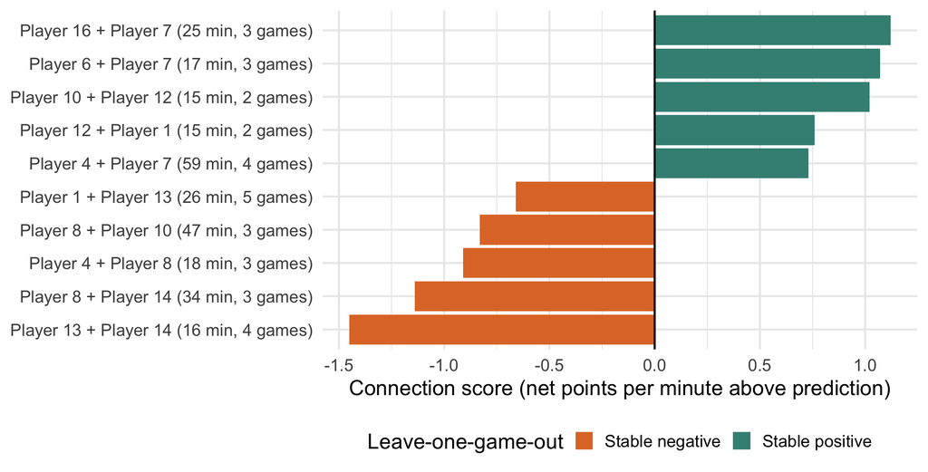

Top and bottom 5 of 73 pairs (at least 15 minutes, 2 games). An association, not proof of chemistry.

## The connection network:

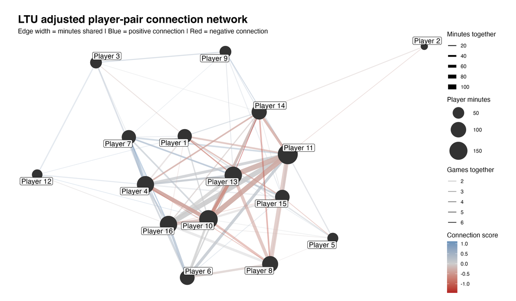

## LTU mostly led comfortably or played close games

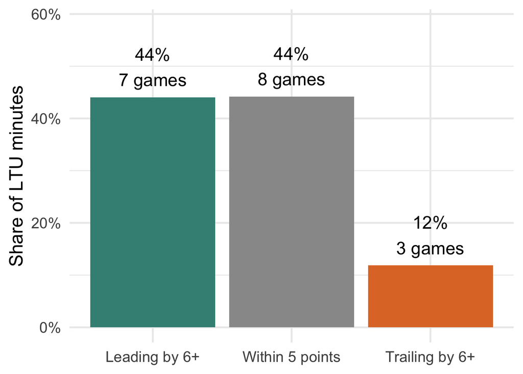

- Clutch window (last 5 minutes, within 5 points): 14 stints, 9.4 minutes, 3 games, so descriptive only
- Only 3 five-player lineups had 5+ minutes in the same game situtation across 2+ games

## Do the scores generalise? Not detectably

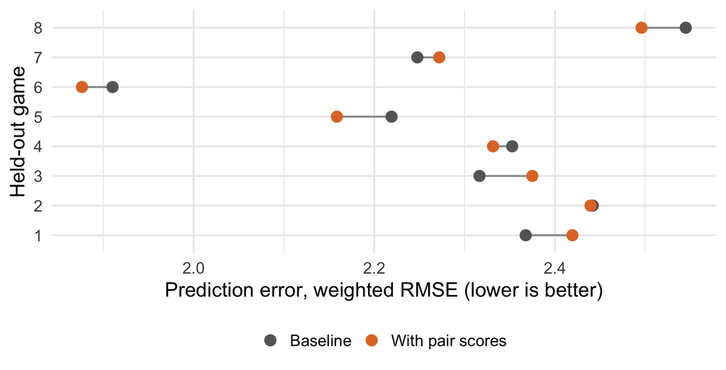

## Zoom out: 2025 was top-heavy in both UBL competitions

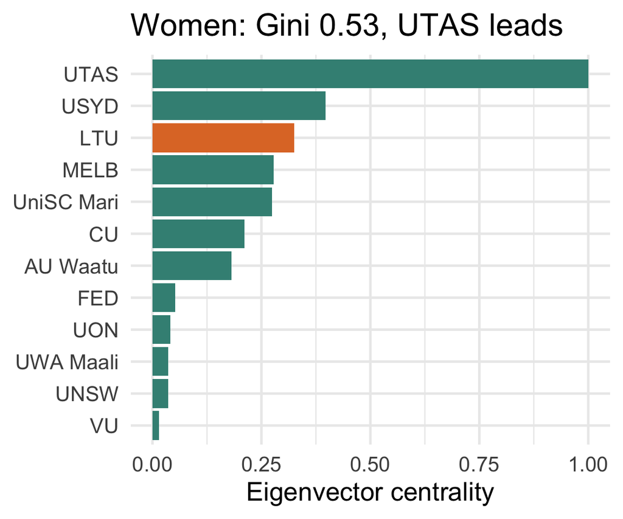

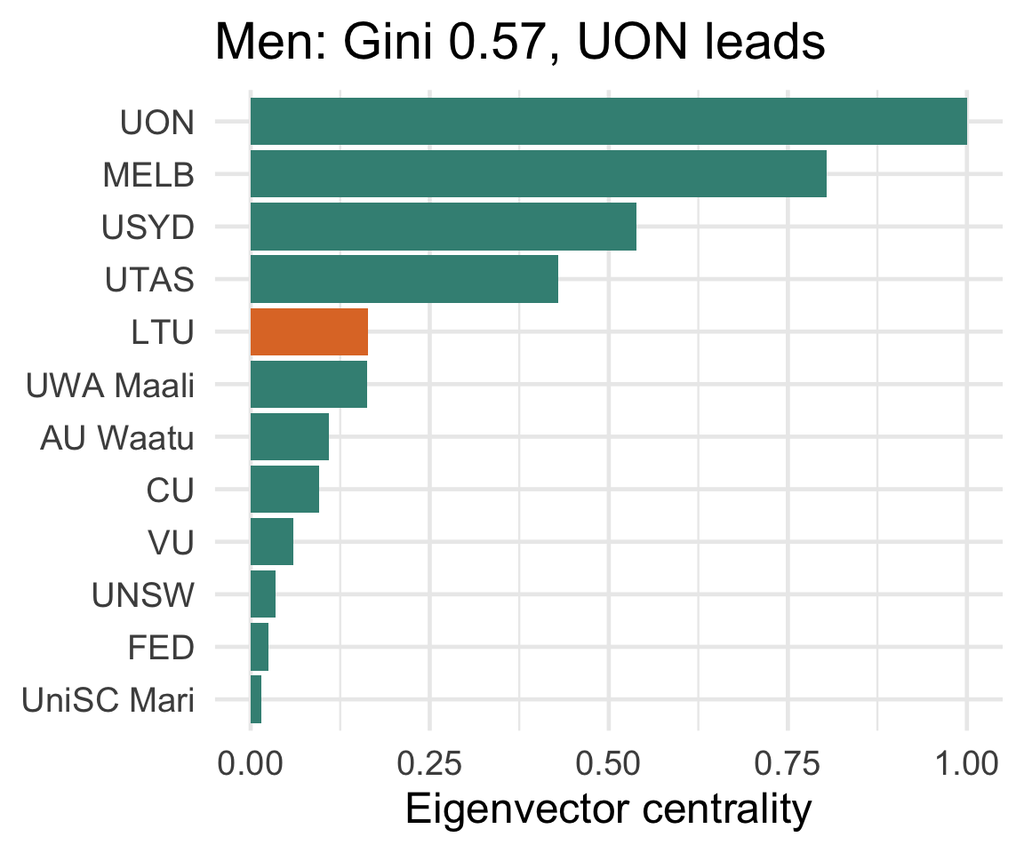

UTAS leads the women but is 4th among the men, so strength is competition-specific. One season only.

## Takeaways

1. Pair scores flag combinations worth a closer look
2. The rotation is broadly connected; bridging sits with two heavily used players
3. Held-out testing found no evidence the scores persist, so treat them as hypotheses for coaches

Limits: one season, 8 games, minutes rather than possessions. Next: more games and seasons.

## Questions

# Backup

## Bridging is concentrated in two heavily used players

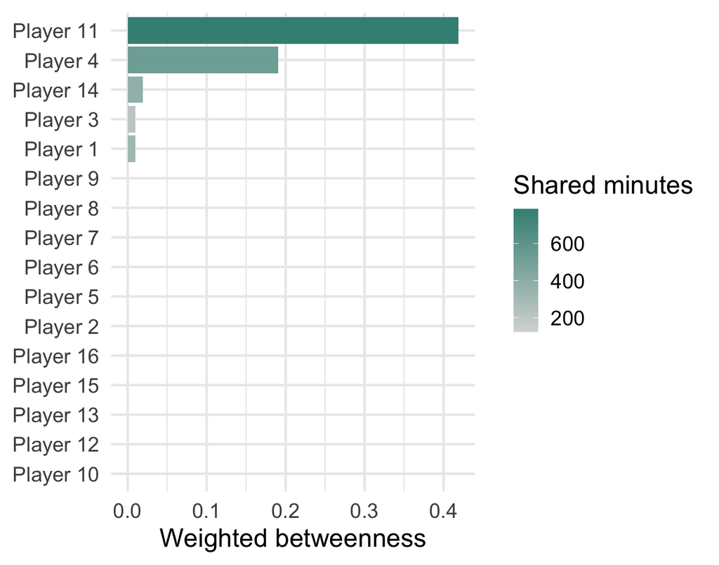

- 112 of 120 possible pairs shared the court
- All 8 gaps involve four players with only 3 to 4 games and under 53 minutes
- Minutes are spread fairly evenly (Gini 0.27), bridging is not (Gini 0.88)

## Stability and data quality

- Leave-one-game-out: drop a game, refit, record whether each pair stays positive (at least 80% = stable)
- Quarter-break lineups are carried over; discrepancies were flagged, not corrected

```r
# Connection score: duration-weighted mean stint residual per pair
stint_resid <- actual_net_per_minute - predicted_net_per_minute
weighted.mean(stint_resid, w = duration_sec)
```

## Centrality measures

- Strength: total shared minutes. Betweenness: lies on short paths between others (more minutes = shorter distance)
- Eigenvector: connected to well-connected players. Gini: concentration, 0 equal to 1 concentrated

**Lineup prediction**
$$y_s = \beta_0 + \sum_p \beta_p x_{sp}
+ \sum_o \delta_o z_{so} + \varepsilon_s$$

**Connection score**
$$C_{ij} =
\frac{\sum_{s \ni i,j} d_s (y_s - \hat{y}_s)}
{\sum_{s \ni i,j} d_s}$$

$y_s$: net points per minute in stint $s$; $x_{sp}$: player $p$ on court; $z_{so}$: opponent; $d_s$: stint length; $\hat{y}_s$: model prediction

## How team eigenvector centrality is calculated

- Each node is a team; arrows point **loser → winner**.
- Edge weights are winning margins.
- Beating highly central teams contributes more to the score.

$$c_i = \frac{1}{\lambda}\sum_j A_{ji}c_j$$

| Symbol | Meaning |
| --- | --- |
| $c_i$ | Centrality of team $i$ |
| $c_j$ | Centrality of defeated team $j$ |
| $A_{ji}$ | Total winning margin on arrows $j \to i$ |
| $\lambda$ | Associated eigenvalue |

**Scaling:** highest score = 1.  
**Gini:** measures concentration of the scores across teams.